```python
import numpy as np
import matplotlib
import matplotlib.pyplot as plt
from scipy import stats
import h5py
import pickle
import pandas as pd
```

```python
higgs_dataset = open ("higgs_100000_pt_250_500.pkl", 'rb')
higgs = pickle.load(higgs_dataset)
qcd_dataset = open ("qcd_100000_pt_250_500.pkl", 'rb')
qcd = pickle.load(qcd_dataset)
```

# 1.

This lab trains on the first dataset with lower pT, and the stacked histograms for the feature varible mass are shown as following:

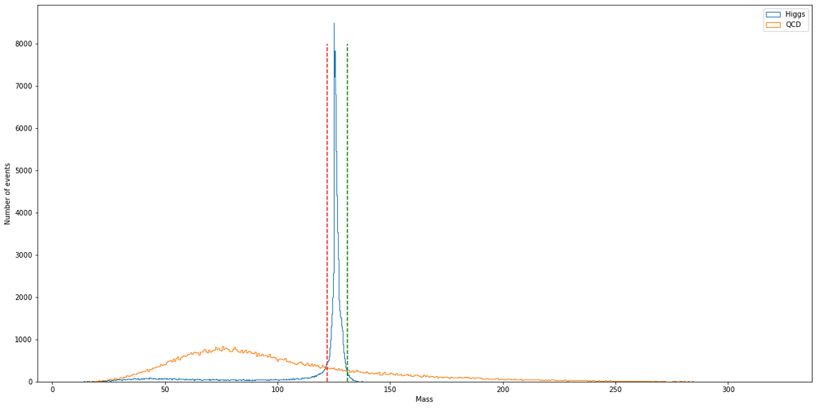

```python
plt.rcParams["figure.figsize"] = (20, 10)
higgs_mass = plt.hist(higgs['mass'],bins=500, histtype='step', label = "Higgs")
qcd_mass = plt.hist(qcd['mass'], bins=500, histtype='step', label = "QCD")
plt.legend()
plt.xlabel('Mass')
plt.ylabel('Number of events')
LoLim = 122
plt.plot(np.linspace(LoLim, LoLim, 8000), np.linspace(0, 8000, 8000), 'r--')
UpLim = 131
plt.plot(np.linspace(UpLim, UpLim, 8000), np.linspace(0, 8000, 8000), 'g--')
plt.show()
```

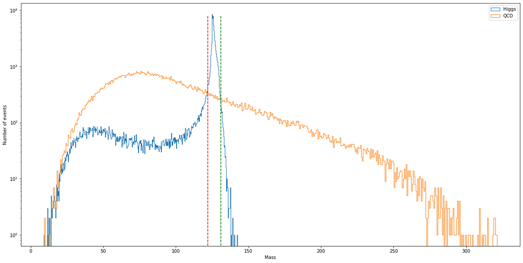

```python
higgs_mass_graph = plt.hist(higgs['mass'],bins=500, histtype='step', label = "Higgs")
qcd_graph_eta = plt.hist(qcd['mass'], bins=500, histtype='step', label = "QCD")
plt.legend()
plt.xlabel('Mass')
plt.ylabel('Number of events')
plt.yscale('log')
LoLim = 122
plt.plot(np.linspace(LoLim, LoLim, 8000), np.linspace(0, 8000, 8000), 'r--')
UpLim = 131
plt.plot(np.linspace(UpLim, UpLim, 8000), np.linspace(0, 8000, 8000), 'g--')
plt.show()
```

```python
higgs_mean = np.mean(higgs)['mass']
qcd_mean  = np.mean(qcd)['mass']
print(higgs_mean)
print(qcd_mean)

n_higgs = 100
n_qcd = 20000
# using Poisson to find the significance
sig_Pois = stats.norm.ppf(stats.poisson.cdf(20100, 20000))
print(sig_Pois)
# with the equation
sig_num = 100/np.sqrt(20000)
print(sig_num)
print(sig_Pois-sig_num)
```

```
114.89238664552165
97.73804095682611
0.7112259282313185
0.7071067811865475
0.00411914704477101
```

# 2.

The way to cut each dataset is defined in the function cutarr. By looking at the graph in question 1, the approximate ranges of upper and lower limits of the cut are 126 - 135, 125 - 115, and then by trying different combinations of each limit we can find the optimal values of them.

```python
def cutarr(arr, ll, ul):
    cut = []
    for m in arr:
        if (m > ll) and (m < ul):
            cut = np.append(cut, m)
    return cut
```

```python
best_cut = 0
bestlower = 0
bestupper = 0
for lower in range(115, 125, 2):
    for upper in range(126, 135, 2):
        higgscut = cutarr(higgs.mass, lower, upper)
        nhiggscut = len(higgscut)/len(higgs.mass)*100
        qcdcut = cutarr(qcd.mass, lower, upper)
        nqcdcut = len(qcdcut)/len(qcd.mass)*20000
        sig = nhiggscut/np.sqrt(nqcdcut)
        if (sig > best_cut):
            best_cut = sig
            bestlower = lower
            bestupper = upper

print(bestupper)
print(bestlower)
print(best_cut)
```

```
128
123
2.9091306427522867
```

```python
# A second search makes the result more refined, with a range from 121 to 125 for lower limit, and a range from 126 to 130 for upper limit,
# both of which the best result from previous search
best_cut = 0
bestlower = 0
bestupper = 0
lowersearch = 121
uppersearch = 126
for lower in range(0, 8):
    for upper in range(0, 8):
        higgscut = cutarr(higgs.mass, lowersearch + lower*0.5, uppersearch + upper*0.5)
        nhiggscut = len(higgscut)/len(higgs.mass)*100
        qcdcut = cutarr(qcd.mass, lowersearch + lower*0.5, uppersearch + upper*0.5)
        nqcdcut = len(qcdcut)/len(qcd.mass)*20000
        sig = nhiggscut/np.sqrt(nqcdcut)
        if (sig > best_cut):
            best_cut = sig
            bestlower = lowersearch + lower*0.5
            bestupper = uppersearch + upper*0.5

print(bestupper)
print(bestlower)
print(best_cut)
```

```
127.0
124.5
3.2159647783278884
```

Upper limit of best cut: 127 Lower limit of best cut: 124.5 Significance of the best cut: 3.22

# 3.

So we want to look at all plots of the features in the data to compare which one has good significance by first glance. First, we need to cut the data set with respect to all features.

```python
UL = 127
LL = 124.5
#higgs_cut = higgs[(higgs['mass'] < UL) & (higgs['mass'] > LL)]

#qcd_cut = qcd[(qcd['mass'] < UL) & (qcd['mass'] > LL)]
higgs_cut = higgs[higgs.mass.between(LL, UL)]
qcd_cut = qcd[qcd.mass.between(LL, UL)]
```

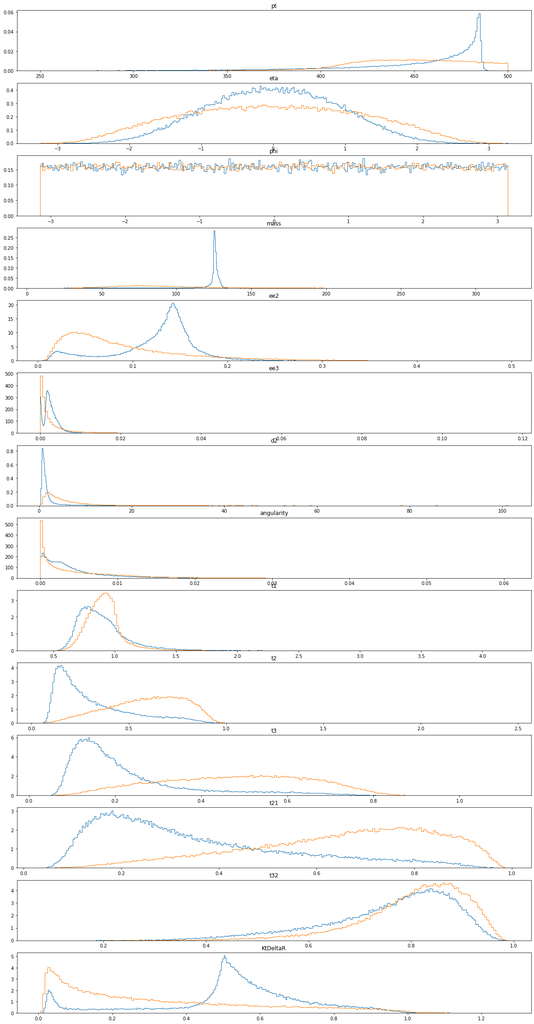

```python
fig, ax = plt.subplots(14, 1, figsize=(20, 40))
i = 0
for feature in qcd.keys():
    ax[i].hist(higgs.get(feature), bins=300, histtype='step', density=True)
    ax[i].hist(qcd.get(feature), bins=200, histtype='step', density=True)
    ax[i].set_title(feature)
    i += 1
```

In each of the plots for pT, ee2, d2,t2, and KtDeltaR, there is a single peak of higgs that stands out far above the qcd background, implying that they have relatively large number of significance as the one of the mass plot.

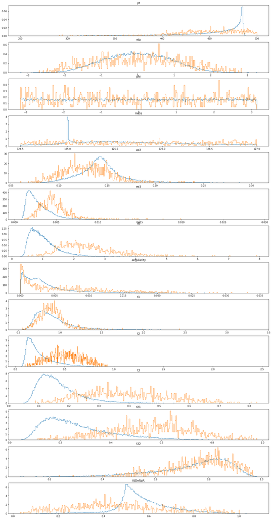

```python
fig, ax_cut = plt.subplots(14, 1, figsize=(20, 40))
i = 0
for feature in qcd_cut.keys():
    ax_cut[i].hist(higgs_cut.get(feature), bins=300, histtype='step', density=True)
    ax_cut[i].hist(qcd_cut.get(feature), bins=300, histtype='step', density=True)
    ax_cut[i].set_title(feature)
    i += 1
```

After the cut, pT. d2, t2, t3, and ktdeltar are the features that has obvious region with relatively large significance.

# 4.

The significances of the features with large significance are calculated.

```python
def sigsearch(feature, LL, UL, variance, step):
    best_cut = 0
    bestlower = 0
    bestupper = 0
    lowersearch = LL-variance
    uppersearch = UL-variance
    total = int(2*variance/step)
    for lower in range(0, total, 1):
        for upper in range(0, total, 1):
            higgscut = cutarr(higgs[feature], lowersearch + lower*step, uppersearch + upper*step)
            nhiggscut = len(higgscut)/len(higgs[feature])*100
            qcdcut = cutarr(qcd[feature], lowersearch + lower*step, uppersearch + upper*step)
            nqcdcut = len(qcdcut)/len(qcd[feature])*20000
            sig = nhiggscut/np.sqrt(nqcdcut)
            if (sig > best_cut):
                best_cut = sig
                bestlower = lowersearch + lower*step
                bestupper = uppersearch + upper*step
    print(bestupper)
    print(bestlower)
    print(best_cut)
    return best_cut, bestlower, bestupper
```

```python
ptsigtemp, llpttemp, ulpttemp = sigsearch('pt', 460, 482, 5, 2)
# using sigsearch again to find more refined value of significance
pTsig, llpT, ulpT = sigsearch('pt', llpttemp, ulpttemp, 2, 0.5)
```

```
485
463
0.7184142681927508
486.5
464.0
0.7606891986509287
```

```python
d2sig, lld2, uld2 = sigsearch('d2', 0.3, 1.4, 0.3, 0.1)
#pTsig, llpT, ulpT = sigsearch_narrow('d2', llpttemp, ulpttemp)
```

[output not shown]

```python
t2sig, llt2, ult2 = sigsearch('t2', 0.1, 0.4, 0.1, 0.02)
```

```
0.30000000000000004
0.06
1.4544493634074487
```

```python
t3sig, llt3, ult3 = sigsearch('t3', 0.1, 0.3, 0.1, 0.02)
```

```
0.19999999999999998
0.06
1.6903293396617862
```

```python
KtDeltaRsig, llKtDeltaR, ulKtDeltaR = sigsearch('KtDeltaR', 0.48, 0.7, 0.05, 0.01)
```

```
0.7299999999999999
0.45999999999999996
1.0899823016160661
```

Among the five features, t3 has a greatest significance, and pT has a smallest significance.

# 5.

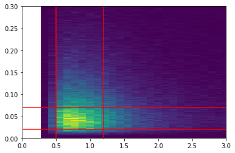

```python
plt.hist2d(higgs['d2'], qcd['ee2'], bins =[300,300])
plt.xlim(0,3)
plt.ylim(0,0.3)
plt.vlines(0.5,0,300, colors='r')
plt.vlines(1.2,0,300, colors='r')
plt.hlines(0.02,0,300, colors='r')
plt.hlines(0.07,0,300, colors='r')
plt.show()
```

The enclosed area by the red lines can be cut into a new graph with higher sensitivity.

# Lab8

1. So in lab 8, we have pseudo-experiment data that needs to be compared with the original data and cut data from previous lab, by overlapping them together in certain features. I choose pt as the feature with the lowest significance and and t3 with the highest significance to compare.

```python
highLumi = pd.read_hdf('data_highLumi_pt_250_500.h5')
highLumi_cut = highLumi[highLumi.mass.between(LL, UL)]
```

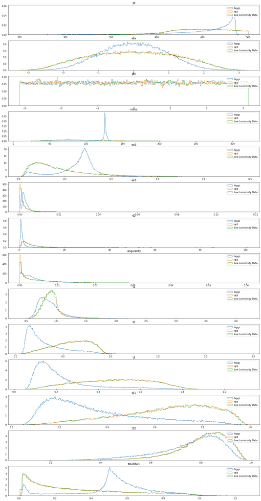

```python
fig, ax_cut = plt.subplots(14, 1, figsize=(20, 40))
i = 0
for feature in qcd.keys():
    ax_cut[i].hist(higgs.get(feature), bins=300, histtype='step', density=True, label='higgs')
    ax_cut[i].hist(qcd.get(feature), bins=300, histtype='step', density=True, label='qcd')
    ax_cut[i].hist(highLumi.get(feature), bins=100, histtype='step', density=True, label='Low Luminosity Data')
    ax_cut[i].set_title(feature)
    ax_cut[i].legend()
    i += 1
```

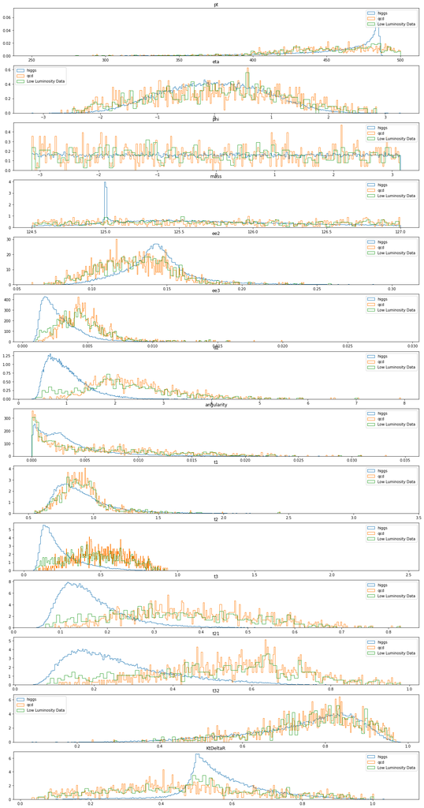

```python
fig, ax_cut = plt.subplots(14, 1, figsize=(20, 40))
i = 0
for feature in qcd_cut.keys():
    ax_cut[i].hist(higgs_cut.get(feature), bins=300, histtype='step', density=True, label='higgs')
    ax_cut[i].hist(qcd_cut.get(feature), bins=300, histtype='step', density=True, label='qcd')
    ax_cut[i].hist(highLumi_cut.get(feature), bins=100, histtype='step', density=True, label='Low Luminosity Data')
    ax_cut[i].set_title(feature)
    ax_cut[i].legend()
    i += 1
```

The pseudo-experiment data is mostly aligned with the qcd data in both original and event selected data plots, but we are able to see there are more small individual peaks occuring in some of the features and located near the region with greater significance of higgs. For the event selected features in the previous lab, we can see small peak being relatively more obvious then the ones in the rest features.

1. Then we need to take a look in the plots with lower luminosity compared to the original data.

```python
lowLumi = pd.read_hdf('data_lowLumi_pt_250_500.h5')
lowLumi_cut = lowLumi[lowLumi.mass.between(LL, UL)]
```

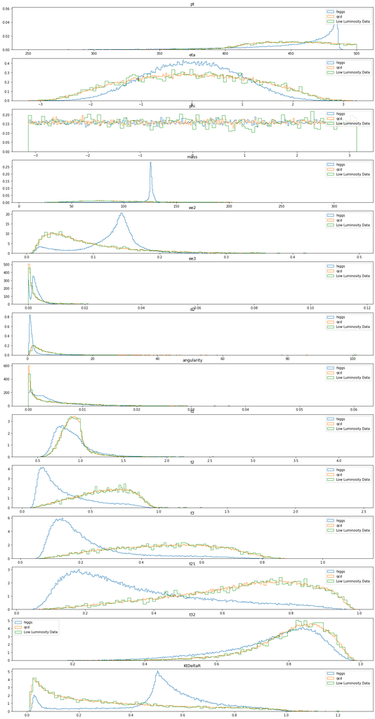

```python
fig, ax_cut = plt.subplots(14, 1, figsize=(20, 40))
i = 0
for feature in qcd.keys():
    ax_cut[i].hist(higgs.get(feature), bins=300, histtype='step', density=True, label='higgs')
    ax_cut[i].hist(qcd.get(feature), bins=300, histtype='step', density=True, label='qcd')
    ax_cut[i].hist(lowLumi.get(feature), bins=100, histtype='step', density=True, label='Low Luminosity Data')
    ax_cut[i].set_title(feature)
    ax_cut[i].legend()
    i += 1
```

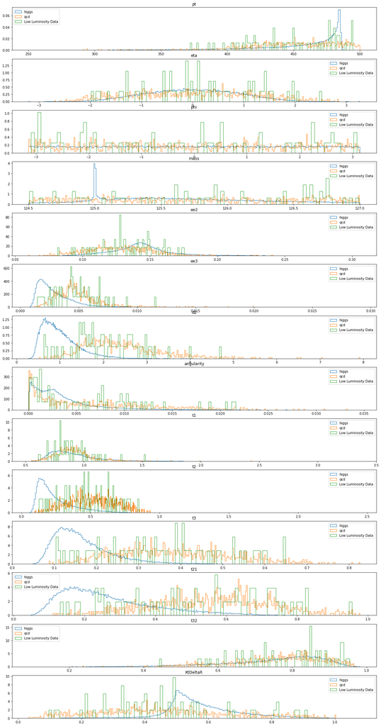

```python
fig, ax_cut = plt.subplots(14, 1, figsize=(20, 40))
i = 0
for feature in qcd_cut.keys():
    ax_cut[i].hist(higgs_cut.get(feature), bins=300, histtype='step', density=True, label='higgs')
    ax_cut[i].hist(qcd_cut.get(feature), bins=300, histtype='step', density=True, label='qcd')
    ax_cut[i].hist(lowLumi_cut.get(feature), bins=100, histtype='step', density=True, label='Low Luminosity Data')
    ax_cut[i].set_title(feature)
    ax_cut[i].legend()
    i += 1
```

```python
higgs_mt3 = higgs.t3.between(0.06, 0.2) & higgs.mass.between(LL, UL)
qcd_mt3 = qcd.t3.between(0.06, 0.2) & qcd.mass.between(LL, UL)
nhiggs_mt3 = len(higgs.mass[higgs_mt3])/len(higgs.mass)*50
nqcd_mt3 = len(qcd.mass[qcd_mt3])/len(qcd.mass)*2000

sig_mt3 = nhiggs_mt3/np.sqrt(nqcd_mt3)
print(sig_mt3)
```

```
14.186862540745222
```

We havemuch greater significance with two cut feature plots combined. The pseudo-experiment low luminosity data distibute in a more discrete way than the data with high luminosity, and the high peaks are not so aligned with the high significance region with the higgs.

1. The expected confidence level upper limit is 440.1, the observed confidence level for qcd upper limit is 430.3, , and the observed confidence level for pseudo-experiment data upper limit is 431.0. The confidence level of the two bserved are very close tothe expected confidence level.

```python
expected = np.percentile(higgs, 95)
observed_qcd = np.percentile(qcd, 95)
observed_pseudo = np.percentile(lowLumi, 95)
print(expected)
print(observed_qcd)
print(observed_pseudo)
```

```
440.11661977740147
430.2609424749775
431.0428111501751
```

1. The 1-sigma uncertainty of the expected 95% confidence level upper limit is 0.20

```python
uncertainty = np.sqrt(expected*expected - observed_pseudo*observed_pseudo)/expected
print(uncertainty)
```

```
0.2020113915162784
```